# PSY 511

Levels

Rick Gilmore

2021-09-01 14:00:31

## Prelude

[video not shown]

## Today’s topics

- Levels of analysis
- Does neuroscience need behavior? Does behavioral science need the brain?

# Levels of analysis

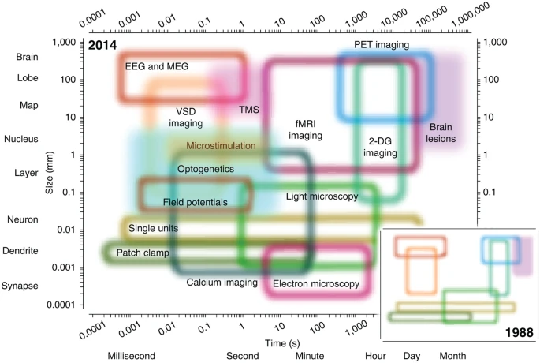

[(Sejnowski, Churchland, & Movshon, 2014)](http://doi.org/10.1038/nn.3839)

## Cognitive science as complexity science [(Favela, 2020)](http://dx.doi.org/10.1002/wcs.1525)

[figure not shown]

[(Favela, 2020)](http://dx.doi.org/10.1002/wcs.1525)

## David Marr (1945-1980)

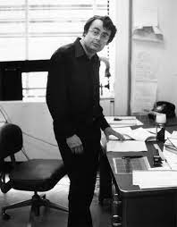

David Marr

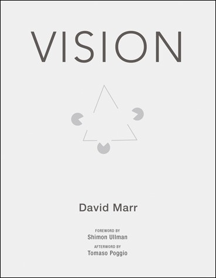

[(Marr, 1980)](https://mitpress.mit.edu/books/vision)

## Marr’s Three Levels

[figure not shown]

[(Favela, 2020)](http://dx.doi.org/10.1002/wcs.1525)

## Scientific “story-telling” at different levels of analysis

- Temporal
  - Short/medium/long
- Spatial
  - Small/medium/large

# Does neuroscience need behavior? Does behavioral science need the brain?

## Discussion of…

Krakauer, J. W., Ghazanfar, A. A., Gomez-Marin, A., MacIver, M. A., & Poeppel, D. (2017). Neuroscience needs behavior: Correcting a reductionist bias. *Neuron*, *93*(3), 480–490. https://dx.doi.org/10.1016/j.neuron.2016.12.041.

## Key points

- Questions ‘often tacit…belief in the reductionist program for understanding the link between brain and behavior’
- Behavior -> understanding; neural inverventions -> causality
- Marr’s 3 levels (computation; algorithm; implementation)

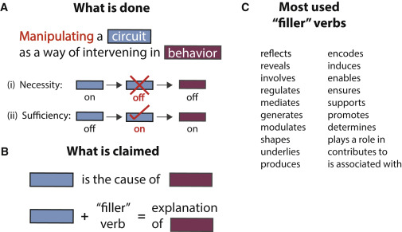

[(Krakauer, Ghazanfar, Gomez-Marin, MacIver, & Poeppel, 2017)](http://dx.doi.org/10.1016/j.neuron.2016.12.041)

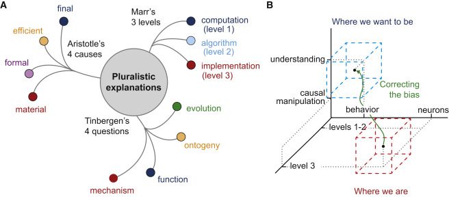

[(Krakauer, Ghazanfar, Gomez-Marin, MacIver, & Poeppel, 2017)](http://dx.doi.org/10.1016/j.neuron.2016.12.041)

## Main points

- Levels of analysis
- Neuroscience needs behavior; behavioral science needs neuroscience

## Your turn

#### 1. Pick two papers you want to read and (better) understand

- Email me APA formatted citation (with DOIs)
- Indicate three concepts/terms you are especially interested in understanding

#### 2. Choose a behavior or mental state you want to (better) understand

- Take an information processing perspective and briefly sketch out (in no more than a short paragraph) the main inputs, outputs, and computations involved.
- When thinking about *outputs* make sure to distinguish between *behaviors* (e.g., movements, facial expressions, vocalizations) and *physiological states* (e.g., changes in heart rate, hormone concentrations in the blood, etc.)

## References

Favela, L. H. (2020). Cognitive science as complexity science. *Wiley Interdisciplinary Reviews. Cognitive Science*, *11*(4), e1525. https://doi.org/10.1002/wcs.1525

Krakauer, J. W., Ghazanfar, A. A., Gomez-Marin, A., MacIver, M. A., & Poeppel, D. (2017). Neuroscience needs behavior: Correcting a reductionist bias. *Neuron*, *93*(3), 480–490. https://doi.org/10.1016/j.neuron.2016.12.041

Marr, D. (1980). *Vision*. Retrieved from https://mitpress.mit.edu/books/vision

Sejnowski, T. J., Churchland, P. S., & Movshon, J. A. (2014). Putting big data to good use in neuroscience. *Nat. Neurosci.*, *17*(11), 1440–1441. https://doi.org/10.1038/nn.3839